### GORUP MEMEBERS :

```
 JAWARIA KHALID
 SYEDA KISAA FATIMA
 TEHREEM ZUBAIR
```

# P and S Project

⦁ For the project, we were told to conduct a survey on any topic, for this purpose e decided to opt for a topic related to environmental issues, as it is a very crucial topic nowadays and we wanted to know about the views of the people on the threats being faced by our environment. So the topic we chose for the survey was "recycling and its importance."

# SURVEY FORM

⦁ The first and most important step was to conduct the survey, for this we made survey forms. While making the survey form we ensured that the questions are not too lengthy or boring, also their relevance to our topic was taken into view. Circulation of the form was done and luckily we had very good responses. In total, we succeeded in collecting more than 200 responses.

Link of the form is given below:

[Click here to visit Google survey form](https://docs.google.com/forms/d/1yoXQaXyrLT0rP85wtnhz_WAksN1qUb7_Xa14bk_rX7I/edit?ts=63982056#responses)

Some of the snippets from the survey form are given below:

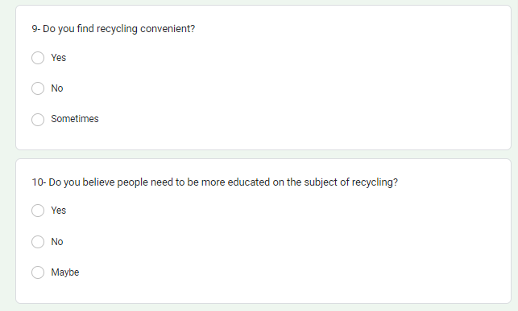

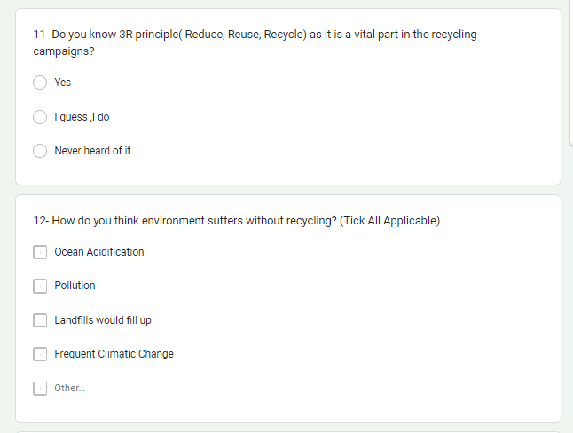

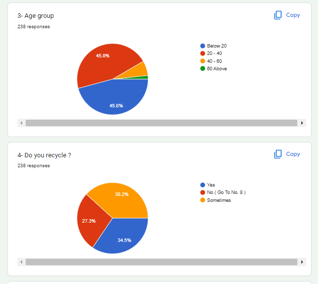

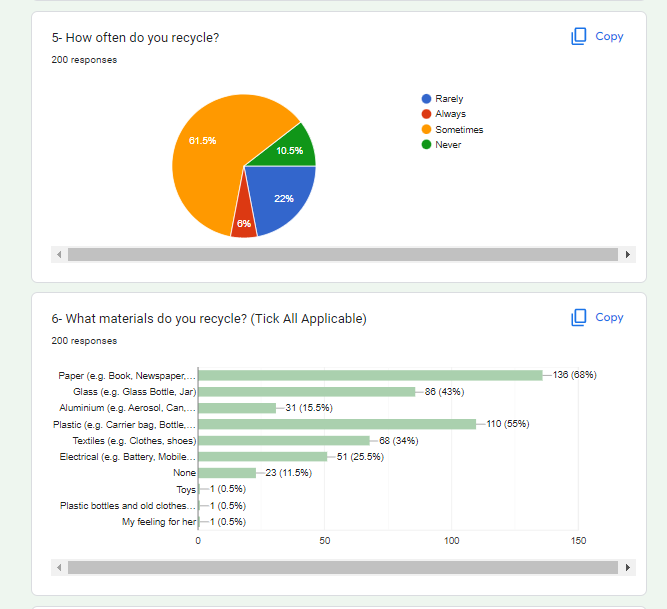

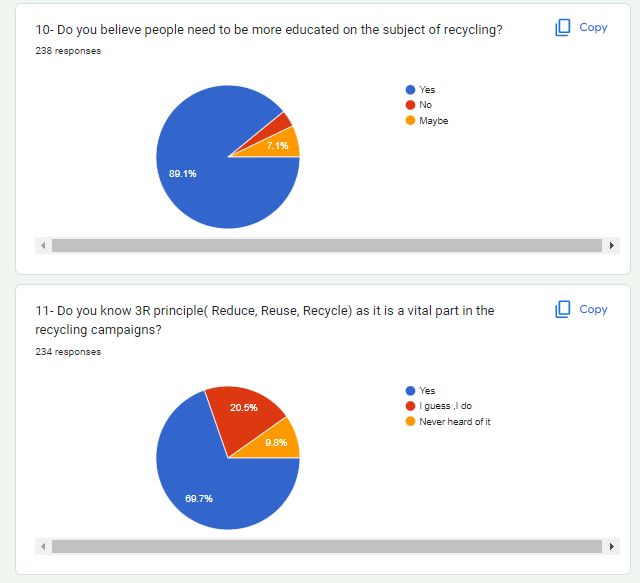

# STATISTICAL ANALYSIS

⦁ After gathering all the responses the next step was to perform the statistical analysis of the data .

⦁ For statistical analysis, we decided to opt for python as our programming language because it has proper data analytics and visualization tools which remained very helpful throughout our project.Python was implemented on Jupiter notebook using the kernel of anaconda.

⦁ Now the whole statistical analysis of data is given below:

```python
#Some important libraries
import pandas as pd
import os
import numpy as np
import matplotlib.pyplot as mp
import seaborn as sns
import scipy
```

```python
import scipy
import scipy.stats
from scipy.stats import norm,t
from statsmodels.stats.proportion import proportions_ztest
```

```python
import warnings
warnings.simplefilter(action='ignore', category=FutureWarning)
```

# The general view of the csv file is given below:

```python
#Load dataset
variable=pd.read_csv('kl.csv')
variable.head()
```

|  | 1- Name | 2- Gender | 3- Age group | 4- Do you recycle ? | 5- How often do you recycle? | 6- What materials do you recycle? (Tick All Applicable) | 7- Why do you recycle? (Tick All Applicable) (Go to No. 9)\n | 8- Why don’t you recycle? (Tick All Applicable) | 9- Do you find recycling convenient? | 10- Do you believe people need to be more educated on the subject of recycling? | 11- Do you know 3R principle( Reduce, Reuse, Recycle) as it is a vital part in the recycling campaigns? | 12- How do you think environment suffers without recycling? (Tick All Applicable) | 13- What are the environmental benefits of recycling? (Tick All Applicable) | 14- Did you know that crushing metals can improve recycling efficiency? | 15- What is the best way to inform you about recycling information?( Tick all applicable ) |
| --- | --- | --- | --- | --- | --- | --- | --- | --- | --- | --- | --- | --- | --- | --- | --- |
| 0 | Tehreem Zubair | Female | Below 20 | Yes | Rarely | Paper (e.g. Book, Newspaper, Magazine, Greet... | “Recycling saves energy.”, “Recycling reduces ... | NaN | Yes | No | Yes | Ocean Acidification, Pollution, Landfills woul... | Conserves energy, Reduce air and water polluti... | No, I will do it from now on | City website, News channels, Through billboard... |
| 1 | Jk | Prefer not to say | 20 - 40 | Yes | Sometimes | None | “Recycling saves energy.” | NaN | Sometimes | Yes | Yes | Ocean Acidification, Pollution, Landfills woul... | Conserves energy | No, I will do it from now on | City website |
| 2 | Tehreem Zubair | Female | Below 20 | Yes | Always | Paper (e.g. Book, Newspaper, Magazine, Greet... | “Recycling saves energy.”, “Recycling is good ... | Trash is an eyesore., “If they paid me, I’d re... | Yes | Yes | Yes | Ocean Acidification, Pollution, Landfills woul... | Conserves energy, Reduce green house gases, co... | Yes , I do it | City website, City Facebook/ page, Water bill ... |
| 3 | syeda kisaa fatima | Female | Below 20 | Sometimes | Rarely | Paper (e.g. Book, Newspaper, Magazine, Greet... | “Recycling reduces landfills.”, “Recycling hel... | “It is just too hard to do.” | Yes | Yes | I guess ,I do | Ocean Acidification, Pollution, Landfills woul... | Conserves energy, Reduce air and water polluti... | Yes , I do it | News channels, Through billboards, Newspaper |
| 4 | Zubair Sadiq | Male | 40 - 60 | Yes | Sometimes | Paper (e.g. Book, Newspaper, Magazine, Greet... | “Recycling saves energy.”, “Recycling reduces ... | Trash is an eyesore., “If they paid me, I’d re... | Yes | Yes | I guess ,I do | Ocean Acidification, Pollution, Landfills woul... | Conserves energy, Reduce air and water polluti... | Yes , I do it | City website, City Facebook/ page, Water bill ... |

# As the ''name'' column was irrelevant so we dropped the name column

```python
variable=variable.drop(['1- Name'],axis=1)
variable.head()
```

|  | 2- Gender | 3- Age group | 4- Do you recycle ? | 5- How often do you recycle? | 6- What materials do you recycle? (Tick All Applicable) | 7- Why do you recycle? (Tick All Applicable) (Go to No. 9)\n | 8- Why don’t you recycle? (Tick All Applicable) | 9- Do you find recycling convenient? | 10- Do you believe people need to be more educated on the subject of recycling? | 11- Do you know 3R principle( Reduce, Reuse, Recycle) as it is a vital part in the recycling campaigns? | 12- How do you think environment suffers without recycling? (Tick All Applicable) | 13- What are the environmental benefits of recycling? (Tick All Applicable) | 14- Did you know that crushing metals can improve recycling efficiency? | 15- What is the best way to inform you about recycling information?( Tick all applicable ) |
| --- | --- | --- | --- | --- | --- | --- | --- | --- | --- | --- | --- | --- | --- | --- |
| 0 | Female | Below 20 | Yes | Rarely | Paper (e.g. Book, Newspaper, Magazine, Greet... | “Recycling saves energy.”, “Recycling reduces ... | NaN | Yes | No | Yes | Ocean Acidification, Pollution, Landfills woul... | Conserves energy, Reduce air and water polluti... | No, I will do it from now on | City website, News channels, Through billboard... |
| 1 | Prefer not to say | 20 - 40 | Yes | Sometimes | None | “Recycling saves energy.” | NaN | Sometimes | Yes | Yes | Ocean Acidification, Pollution, Landfills woul... | Conserves energy | No, I will do it from now on | City website |
| 2 | Female | Below 20 | Yes | Always | Paper (e.g. Book, Newspaper, Magazine, Greet... | “Recycling saves energy.”, “Recycling is good ... | Trash is an eyesore., “If they paid me, I’d re... | Yes | Yes | Yes | Ocean Acidification, Pollution, Landfills woul... | Conserves energy, Reduce green house gases, co... | Yes , I do it | City website, City Facebook/ page, Water bill ... |
| 3 | Female | Below 20 | Sometimes | Rarely | Paper (e.g. Book, Newspaper, Magazine, Greet... | “Recycling reduces landfills.”, “Recycling hel... | “It is just too hard to do.” | Yes | Yes | I guess ,I do | Ocean Acidification, Pollution, Landfills woul... | Conserves energy, Reduce air and water polluti... | Yes , I do it | News channels, Through billboards, Newspaper |
| 4 | Male | 40 - 60 | Yes | Sometimes | Paper (e.g. Book, Newspaper, Magazine, Greet... | “Recycling saves energy.”, “Recycling reduces ... | Trash is an eyesore., “If they paid me, I’d re... | Yes | Yes | I guess ,I do | Ocean Acidification, Pollution, Landfills woul... | Conserves energy, Reduce air and water polluti... | Yes , I do it | City website, City Facebook/ page, Water bill ... |

# ⦁ The names of the columns were changed to shorter names for easy handling

```python
change_names={'3- Age group ':'age','4- Do you recycle ?':'recycle','2- Gender':'gender',
             '5- How often do you recycle?':'recycling how often',
             '6- What materials do you recycle? (Tick All Applicable)':'recycling material',
             '7- Why do you recycle? (Tick All Applicable) (Go to No. 9)\n':'recycling cause',
             '8- Why don’t you recycle? (Tick All Applicable)':'no recycling reason',
             '9- Do you find recycling convenient?':'conviniency',
             '10- Do you believe people need to be more educated on the subject of recycling?':'recycling education',
             '11- Do you know 3R principle( Reduce, Reuse, Recycle) as it is a vital part in the recycling campaigns?':'3R principle',
             '12- How do you think environment suffers without recycling? (Tick All Applicable)':'effect on environment',
             '13- What are the environmental benefits of recycling? (Tick All Applicable)':'benefits of recycling',
               '14- Did you know that crushing metals can improve recycling efficiency?':'crushing metals',
               '15- What is the best way to inform you about recycling information? ( Tick all applicable )':'best awareness platforms'}
variable = variable.rename(columns=change_names)
variable.head()
```

|  | gender | age | recycle | recycling how often | recycling material | recycling cause | no recycling reason | conviniency | recycling education | 3R principle | effect on environment | benefits of recycling | crushing metals | 15- What is the best way to inform you about recycling information?( Tick all applicable ) |
| --- | --- | --- | --- | --- | --- | --- | --- | --- | --- | --- | --- | --- | --- | --- |
| 0 | Female | Below 20 | Yes | Rarely | Paper (e.g. Book, Newspaper, Magazine, Greet... | “Recycling saves energy.”, “Recycling reduces ... | NaN | Yes | No | Yes | Ocean Acidification, Pollution, Landfills woul... | Conserves energy, Reduce air and water polluti... | No, I will do it from now on | City website, News channels, Through billboard... |
| 1 | Prefer not to say | 20 - 40 | Yes | Sometimes | None | “Recycling saves energy.” | NaN | Sometimes | Yes | Yes | Ocean Acidification, Pollution, Landfills woul... | Conserves energy | No, I will do it from now on | City website |
| 2 | Female | Below 20 | Yes | Always | Paper (e.g. Book, Newspaper, Magazine, Greet... | “Recycling saves energy.”, “Recycling is good ... | Trash is an eyesore., “If they paid me, I’d re... | Yes | Yes | Yes | Ocean Acidification, Pollution, Landfills woul... | Conserves energy, Reduce green house gases, co... | Yes , I do it | City website, City Facebook/ page, Water bill ... |
| 3 | Female | Below 20 | Sometimes | Rarely | Paper (e.g. Book, Newspaper, Magazine, Greet... | “Recycling reduces landfills.”, “Recycling hel... | “It is just too hard to do.” | Yes | Yes | I guess ,I do | Ocean Acidification, Pollution, Landfills woul... | Conserves energy, Reduce air and water polluti... | Yes , I do it | News channels, Through billboards, Newspaper |
| 4 | Male | 40 - 60 | Yes | Sometimes | Paper (e.g. Book, Newspaper, Magazine, Greet... | “Recycling saves energy.”, “Recycling reduces ... | Trash is an eyesore., “If they paid me, I’d re... | Yes | Yes | I guess ,I do | Ocean Acidification, Pollution, Landfills woul... | Conserves energy, Reduce air and water polluti... | Yes , I do it | City website, City Facebook/ page, Water bill ... |

# Data Engineering

### For statistical analysis we needed data in numeric form but we only had had data in the form of strings so we did some coding and generated code for the columns like in column "recycle" ,when we coded the coded column recycle(integer) was created that contained a code for the column in numeric form .Here in the given figure 1 means Sometimes , 2 means no,0 means yes.

```python
variable['recycle(integer)']=pd.factorize(variable.recycle)[0]
variable.head()
```

|  | gender | age | recycle | recycling how often | recycling material | recycling cause | no recycling reason | conviniency | recycling education | 3R principle | effect on environment | benefits of recycling | crushing metals | 15- What is the best way to inform you about recycling information?( Tick all applicable ) | recycle(integer) |
| --- | --- | --- | --- | --- | --- | --- | --- | --- | --- | --- | --- | --- | --- | --- | --- |
| 0 | Female | Below 20 | Yes | Rarely | Paper (e.g. Book, Newspaper, Magazine, Greet... | “Recycling saves energy.”, “Recycling reduces ... | NaN | Yes | No | Yes | Ocean Acidification, Pollution, Landfills woul... | Conserves energy, Reduce air and water polluti... | No, I will do it from now on | City website, News channels, Through billboard... | 0 |
| 1 | Prefer not to say | 20 - 40 | Yes | Sometimes | None | “Recycling saves energy.” | NaN | Sometimes | Yes | Yes | Ocean Acidification, Pollution, Landfills woul... | Conserves energy | No, I will do it from now on | City website | 0 |
| 2 | Female | Below 20 | Yes | Always | Paper (e.g. Book, Newspaper, Magazine, Greet... | “Recycling saves energy.”, “Recycling is good ... | Trash is an eyesore., “If they paid me, I’d re... | Yes | Yes | Yes | Ocean Acidification, Pollution, Landfills woul... | Conserves energy, Reduce green house gases, co... | Yes , I do it | City website, City Facebook/ page, Water bill ... | 0 |
| 3 | Female | Below 20 | Sometimes | Rarely | Paper (e.g. Book, Newspaper, Magazine, Greet... | “Recycling reduces landfills.”, “Recycling hel... | “It is just too hard to do.” | Yes | Yes | I guess ,I do | Ocean Acidification, Pollution, Landfills woul... | Conserves energy, Reduce air and water polluti... | Yes , I do it | News channels, Through billboards, Newspaper | 1 |
| 4 | Male | 40 - 60 | Yes | Sometimes | Paper (e.g. Book, Newspaper, Magazine, Greet... | “Recycling saves energy.”, “Recycling reduces ... | Trash is an eyesore., “If they paid me, I’d re... | Yes | Yes | I guess ,I do | Ocean Acidification, Pollution, Landfills woul... | Conserves energy, Reduce air and water polluti... | Yes , I do it | City website, City Facebook/ page, Water bill ... | 0 |

```python
variable['gender(integer)']=pd.factorize(variable.gender)[0]
variable.head()
```

|  | gender | age | recycle | recycling how often | recycling material | recycling cause | no recycling reason | conviniency | recycling education | 3R principle | effect on environment | benefits of recycling | crushing metals | 15- What is the best way to inform you about recycling information?( Tick all applicable ) | recycle(integer) | gender(integer) |
| --- | --- | --- | --- | --- | --- | --- | --- | --- | --- | --- | --- | --- | --- | --- | --- | --- |
| 0 | Female | Below 20 | Yes | Rarely | Paper (e.g. Book, Newspaper, Magazine, Greet... | “Recycling saves energy.”, “Recycling reduces ... | NaN | Yes | No | Yes | Ocean Acidification, Pollution, Landfills woul... | Conserves energy, Reduce air and water polluti... | No, I will do it from now on | City website, News channels, Through billboard... | 0 | 0 |
| 1 | Prefer not to say | 20 - 40 | Yes | Sometimes | None | “Recycling saves energy.” | NaN | Sometimes | Yes | Yes | Ocean Acidification, Pollution, Landfills woul... | Conserves energy | No, I will do it from now on | City website | 0 | 1 |
| 2 | Female | Below 20 | Yes | Always | Paper (e.g. Book, Newspaper, Magazine, Greet... | “Recycling saves energy.”, “Recycling is good ... | Trash is an eyesore., “If they paid me, I’d re... | Yes | Yes | Yes | Ocean Acidification, Pollution, Landfills woul... | Conserves energy, Reduce green house gases, co... | Yes , I do it | City website, City Facebook/ page, Water bill ... | 0 | 0 |
| 3 | Female | Below 20 | Sometimes | Rarely | Paper (e.g. Book, Newspaper, Magazine, Greet... | “Recycling reduces landfills.”, “Recycling hel... | “It is just too hard to do.” | Yes | Yes | I guess ,I do | Ocean Acidification, Pollution, Landfills woul... | Conserves energy, Reduce air and water polluti... | Yes , I do it | News channels, Through billboards, Newspaper | 1 | 0 |
| 4 | Male | 40 - 60 | Yes | Sometimes | Paper (e.g. Book, Newspaper, Magazine, Greet... | “Recycling saves energy.”, “Recycling reduces ... | Trash is an eyesore., “If they paid me, I’d re... | Yes | Yes | I guess ,I do | Ocean Acidification, Pollution, Landfills woul... | Conserves energy, Reduce air and water polluti... | Yes , I do it | City website, City Facebook/ page, Water bill ... | 0 | 2 |

```python
variable['age(integer)']=pd.factorize(variable.age)[0]
variable.head()
```

|  | gender | age | recycle | recycling how often | recycling material | recycling cause | no recycling reason | conviniency | recycling education | 3R principle | effect on environment | benefits of recycling | crushing metals | 15- What is the best way to inform you about recycling information?( Tick all applicable ) | recycle(integer) | gender(integer) | age(integer) |
| --- | --- | --- | --- | --- | --- | --- | --- | --- | --- | --- | --- | --- | --- | --- | --- | --- | --- |
| 0 | Female | Below 20 | Yes | Rarely | Paper (e.g. Book, Newspaper, Magazine, Greet... | “Recycling saves energy.”, “Recycling reduces ... | NaN | Yes | No | Yes | Ocean Acidification, Pollution, Landfills woul... | Conserves energy, Reduce air and water polluti... | No, I will do it from now on | City website, News channels, Through billboard... | 0 | 0 | 0 |
| 1 | Prefer not to say | 20 - 40 | Yes | Sometimes | None | “Recycling saves energy.” | NaN | Sometimes | Yes | Yes | Ocean Acidification, Pollution, Landfills woul... | Conserves energy | No, I will do it from now on | City website | 0 | 1 | 1 |
| 2 | Female | Below 20 | Yes | Always | Paper (e.g. Book, Newspaper, Magazine, Greet... | “Recycling saves energy.”, “Recycling is good ... | Trash is an eyesore., “If they paid me, I’d re... | Yes | Yes | Yes | Ocean Acidification, Pollution, Landfills woul... | Conserves energy, Reduce green house gases, co... | Yes , I do it | City website, City Facebook/ page, Water bill ... | 0 | 0 | 0 |
| 3 | Female | Below 20 | Sometimes | Rarely | Paper (e.g. Book, Newspaper, Magazine, Greet... | “Recycling reduces landfills.”, “Recycling hel... | “It is just too hard to do.” | Yes | Yes | I guess ,I do | Ocean Acidification, Pollution, Landfills woul... | Conserves energy, Reduce air and water polluti... | Yes , I do it | News channels, Through billboards, Newspaper | 1 | 0 | 0 |
| 4 | Male | 40 - 60 | Yes | Sometimes | Paper (e.g. Book, Newspaper, Magazine, Greet... | “Recycling saves energy.”, “Recycling reduces ... | Trash is an eyesore., “If they paid me, I’d re... | Yes | Yes | I guess ,I do | Ocean Acidification, Pollution, Landfills woul... | Conserves energy, Reduce air and water polluti... | Yes , I do it | City website, City Facebook/ page, Water bill ... | 0 | 2 | 2 |

```python
variable['conviniency(integer)']=pd.factorize(variable.conviniency)[0]
variable.tail()
```

|  | gender | age | recycle | recycling how often | recycling material | recycling cause | no recycling reason | conviniency | recycling education | 3R principle | effect on environment | benefits of recycling | crushing metals | 15- What is the best way to inform you about recycling information?( Tick all applicable ) | recycle(integer) | gender(integer) | age(integer) | conviniency(integer) |
| --- | --- | --- | --- | --- | --- | --- | --- | --- | --- | --- | --- | --- | --- | --- | --- | --- | --- | --- |
| 232 | Prefer not to say | Below 20 | Sometimes | Always | Paper (e.g. Book, Newspaper, Magazine, Greet... | “Recycling saves energy.”, Paisy hi nhi h…jo h... | “If they paid me, I’d recycle.”, Mjhy nhi pata h🦫 | Yes | No | Yes | Ocean Acidification, Pollution, Landfills woul... | Conserves energy, Reduce air and water polluti... | Yes , I do it | Through Neighborhood, Class group mn msg send ... | 1 | 1 | 0 | 0 |
| 233 | Female | Below 20 | No ( Go To No. 8 ) | Rarely | Plastic (e.g. Carrier bag, Bottle, Yoghurt p... | better for my own convenience than to throw ou... | as ticked earlier 'i do recycle whatever helpf... | Yes | Yes | Yes | Pollution, Frequent Climatic Change | Conserves energy, Reduce air and water polluti... | Yes , I do it | Through billboards | 2 | 0 | 0 | 0 |
| 234 | Female | 20 - 40 | Sometimes | Sometimes | Paper (e.g. Book, Newspaper, Magazine, Greet... | “Recycling saves energy.”, “Recycling reduces ... | “If they paid me, I’d recycle.” | Sometimes | Yes | Yes | Pollution, Frequent Climatic Change | Cleaner environment | Yes , I do it | City website, City Facebook/ page, News channels | 1 | 0 | 1 | 1 |
| 235 | Male | 20 - 40 | Sometimes | Sometimes | Glass (e.g. Glass Bottle, Jar), Textiles (... | “Recycling saves energy.”, “Recycling preserve... | NaN | Sometimes | Yes | I guess ,I do | Pollution, Landfills would fill up, Frequent C... | Reduce air and water pollution, Reduce green h... | Yes , but I don't care | City Facebook/ page, News channels, Newspaper | 1 | 2 | 1 | 1 |
| 236 | Male | Below 20 | Sometimes | Sometimes | Paper (e.g. Book, Newspaper, Magazine, Greet... | “Recycling is good for the economy.” | NaN | Yes | Yes | Yes | Ocean Acidification, Pollution, Landfills woul... | Conserves energy, Reduce air and water polluti... | Yes , I do it | City Facebook/ page | 1 | 2 | 0 | 0 |

## OUTLIERS REMOVAL:

```python
def outlier_remover(variable):
    for col in variable.columns:
        if pd.api.types.is_numeric_dtype(variable[col]):
            Q1=variable[col].quantile(0.25)
            Q3=variable[col].quantile(0.75)
            IQR=Q3-Q1
            lower=Q1-1.5*IQR
            upper=Q3+1.5*IQR
            print(col)
            if lower<0:
                lower=0
            print('Q1 = ',Q1,' Q3 = ',Q3,' IQR = ',IQR)
            print(lower ,'>',col,'<',upper)
            mp.figure(figsize=(15,5))
            g=sns.boxenplot(variable[col],width=0.3)
            mp.show()
            variable=variable[(variable[col]>=lower) & (variable[col]<=upper)]
    return variable
```

```
recycle(integer)
Q1 =  0.0  Q3 =  2.0  IQR =  2.0
0 > recycle(integer) < 5.0
```

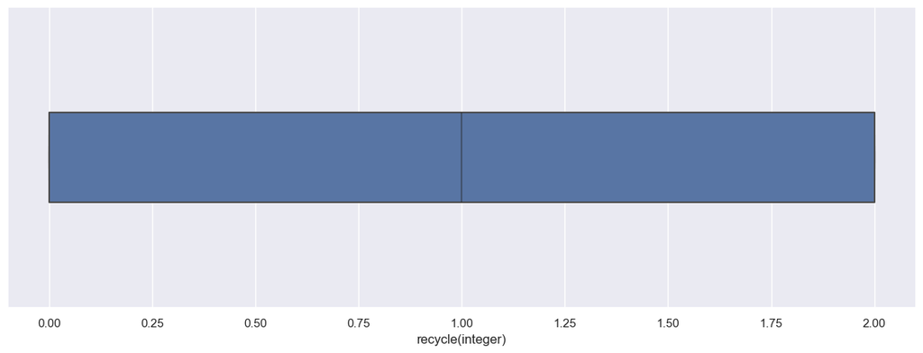

```
gender(integer)
Q1 =  0.0  Q3 =  2.0  IQR =  2.0
0 > gender(integer) < 5.0
```

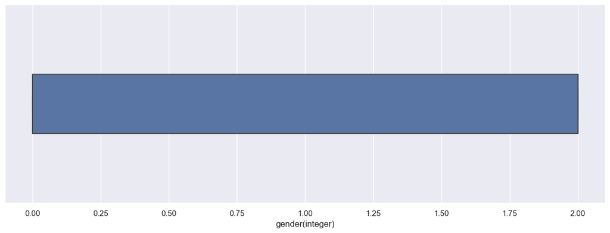

```
age(integer)
Q1 =  0.0  Q3 =  1.0  IQR =  1.0
0 > age(integer) < 2.5
```

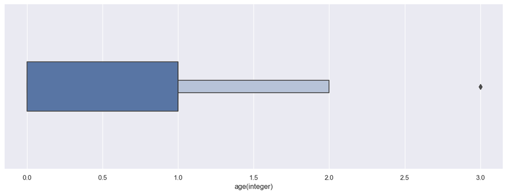

```
conviniency(integer)
Q1 =  0.0  Q3 =  1.0  IQR =  1.0
0 > conviniency(integer) < 2.5
```

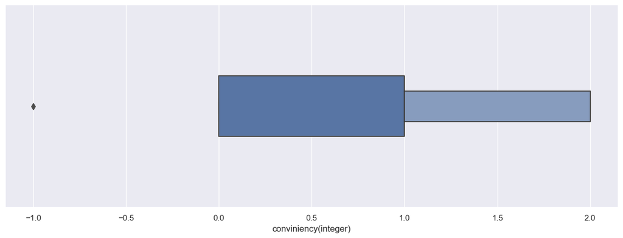

```python
variable=outlier_remover(variable)
```

```python
len(variable)
```

```
231
```

## VARIABLE INFO

```python
variable.info()
```

```
<class 'pandas.core.frame.DataFrame'>
Int64Index: 231 entries, 0 to 236
Data columns (total 18 columns):
 #   Column                                                                                       Non-Null Count  Dtype
---  ------                                                                                       --------------  -----
 0   gender                                                                                       231 non-null    object
 1   age                                                                                          231 non-null    object
 2   recycle                                                                                      231 non-null    object
 3   recycling how often                                                                          195 non-null    object
 4   recycling material                                                                           195 non-null    object
 5   recycling cause                                                                              183 non-null    object
 6   no recycling reason                                                                          128 non-null    object
 7   conviniency                                                                                  231 non-null    object
 8   recycling education                                                                          231 non-null    object
 9   3R principle                                                                                 228 non-null    object
 10  effect on environment                                                                        224 non-null    object
 11  benefits of recycling                                                                        228 non-null    object
 12  crushing metals                                                                              225 non-null    object
 13   15- What is the best way to inform you about recycling information?( Tick all applicable )  226 non-null    object
 14  recycle(integer)                                                                             231 non-null    int64
 15  gender(integer)                                                                              231 non-null    int64
 16  age(integer)                                                                                 231 non-null    int64
 17  conviniency(integer)                                                                         231 non-null    int64
dtypes: int64(4), object(14)
memory usage: 34.3+ KB
```

```python
variable.describe()
```

|  | recycle(integer) | gender(integer) | age(integer) | conviniency(integer) |
| --- | --- | --- | --- | --- |
| count | 231.00000 | 231.000000 | 231.000000 | 231.000000 |
| mean | 0.91342 | 1.056277 | 0.606061 | 0.753247 |
| std | 0.77535 | 0.987461 | 0.615564 | 0.760249 |
| min | 0.00000 | 0.000000 | 0.000000 | 0.000000 |
| 25% | 0.00000 | 0.000000 | 0.000000 | 0.000000 |
| 50% | 1.00000 | 2.000000 | 1.000000 | 1.000000 |
| 75% | 2.00000 | 2.000000 | 1.000000 | 1.000000 |
| max | 2.00000 | 2.000000 | 2.000000 | 2.000000 |

```python
variable['recycle(integer)'].value_counts()
##note 1:yes ,2:sometimes, 0:no
```

```
1    91
0    80
2    60
Name: recycle(integer), dtype: int64
```

```python
variable['no recycling reason'].value_counts()
```

```
“It is just too hard to do.”                                                                                                                                                                                                                      52
Trash is an eyesore.                                                                                                                                                                                                                              13
“Recycling doesn’t make a difference. So why do it?”                                                                                                                                                                                              11
“If they paid me, I’d recycle.”                                                                                                                                                                                                                   11
Trash is an eyesore., “If they paid me, I’d recycle.”, “Recycling doesn’t make a difference. So why do it?”, “It is just too hard to do.”                                                                                                          4
Trash is an eyesore., “It is just too hard to do.”                                                                                                                                                                                                 3
Trash is an eyesore., “If they paid me, I’d recycle.”, “It is just too hard to do.”                                                                                                                                                                2
“If they paid me, I’d recycle.”, “Recycling doesn’t make a difference. So why do it?”                                                                                                                                                              2
“If they paid me, I’d recycle.”, “Recycling doesn’t make a difference. So why do it?”, “It is just too hard to do.”                                                                                                                                1
I usually do it myself or any occupant from my home does it.                                                                                                                                                                                       1
.                                                                                                                                                                                                                                                  1
Trash is an eyesore., “If they paid me, I’d recycle.”                                                                                                                                                                                              1
I don't get a chance                                                                                                                                                                                                                               1
I dont know where to recycle.                                                                                                                                                                                                                      1
Just throw the trash in the trash bin, recycling takes time                                                                                                                                                                                        1
I do recycle                                                                                                                                                                                                                                       1
No mechanism / option available                                                                                                                                                                                                                    1
```

[output cut: 22 more lines]

```python
variable['3R principle'].value_counts()
```

```
Yes                  159
I guess ,I do         47
Never heard of it     22
Name: 3R principle, dtype: int64
```

## STATISTICAL GRAPHS

### DOT PLOTS:

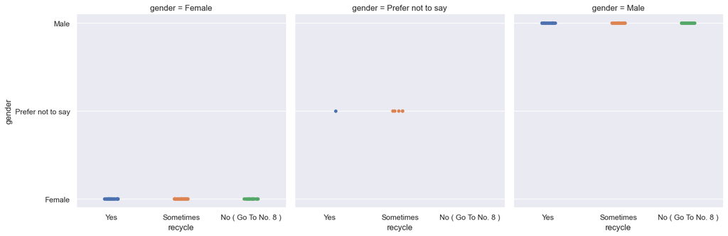

```python
sns.catplot(x='recycle',y='gender', col='gender',data=variable,kind="strip")
# Show the plot
mp.show()
```

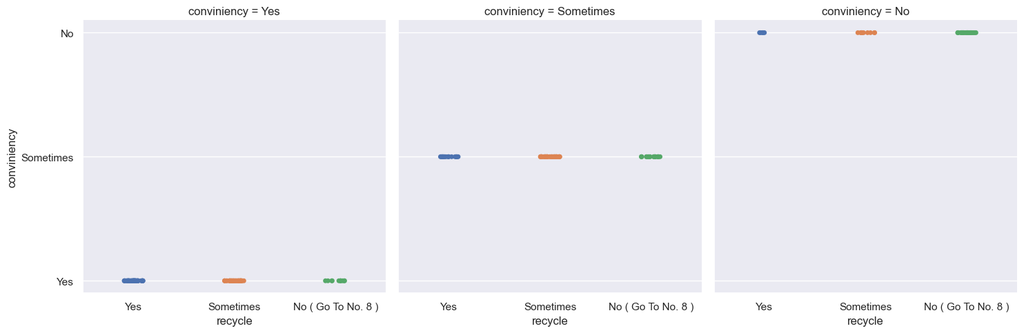

```python
sns.catplot(x='recycle',y='conviniency', col='conviniency',data=variable,kind="strip")
mp.show()
```

### PIE CHARTS

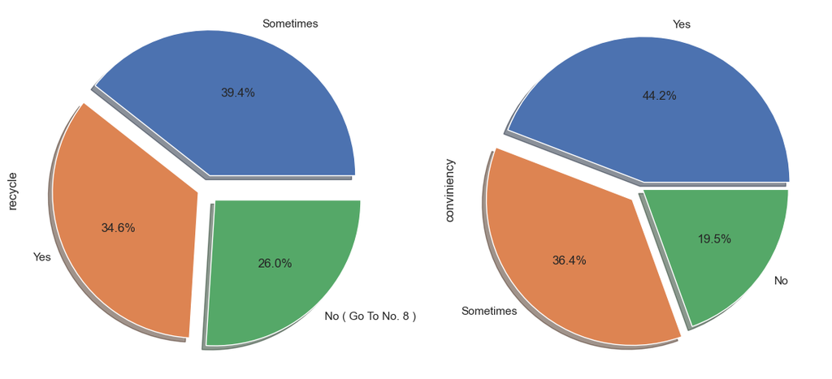

```python
fig, ax = mp.subplots(1,2,figsize=(14,14))
mp.subplot(1, 2, 1)
variable['recycle'].value_counts().plot.pie(shadow=True,autopct='%1.1f%%',explode=[0.1,0.05,0.1])
mp.subplot(1, 2, 2)
variable['conviniency'].value_counts().plot.pie(shadow=True,autopct='%1.1f%%',explode=[0.05,0.1,0])
mp.show()
```

### RELATIONSHIP BETWEEN DIFFERNENT ENTITIES

[figure not shown]

```python
fig,ax=mp.subplots(figsize=(10,6))
variable1=variable[variable['recycle']=='Yes']
variable2=variable[variable['recycle']=='No']
variable3=variable[variable['recycle']=='Sometimes']
Sometimes=pd.DataFrame(variable1.groupby('age')['gender(integer)'].mean())
No=pd.DataFrame(variable2.groupby('age')['gender(integer)'].mean())
Yes=pd.DataFrame(variable3.groupby('age')['gender(integer)'].mean())
ax.plot(Sometimes.index,Sometimes['gender(integer)'],marker='*',linestyle='--',label='Sometimes',color='g');
ax.plot(No.index,No['gender(integer)'],marker='^',linestyle='--',label='No',color='black');
ax.plot(Yes.index,Yes['gender(integer)'],marker='*',label='Yes',color='r');
mp.legend(title="Do you recycle",fancybox=True);
mp
mp.title('age and gender vs do you recycle');
mp.xlabel('age')
mp.ylabel('gender')
mp.show()
```

### TABLES

```python
recycle=variable[variable['recycle']=='Yes']
table = recycle.pivot_table(index=['gender', 'conviniency'], values='recycle', aggfunc='count')
```

```python
table
```

| gender | conviniency | recycle |
| --- | --- | --- |
| Female | No | 1 |
|  | Sometimes | 10 |
|  | Yes | 28 |
| Male | No | 4 |
|  | Sometimes | 9 |
|  | Yes | 27 |
| Prefer not to say | Sometimes | 1 |

## BAR CHARTS :

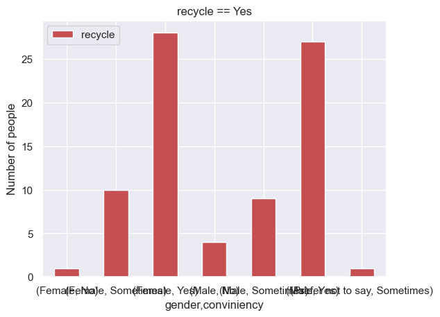

```python
table.plot(kind='bar',color='r')
mp.title('recycle == Yes')
mp.tick_params(rotation=0)
mp.ylabel('Number of people')
mp.show()
```

```python
recycle=variable[variable['3R principle']=='Yes']
table = recycle.pivot_table(index=['gender', '3R principle'], values='recycle', aggfunc='count')
table
```

| gender | 3R principle | recycle |
| --- | --- | --- |
| Female | Yes | 74 |
| Male | Yes | 79 |
| Prefer not to say | Yes | 6 |

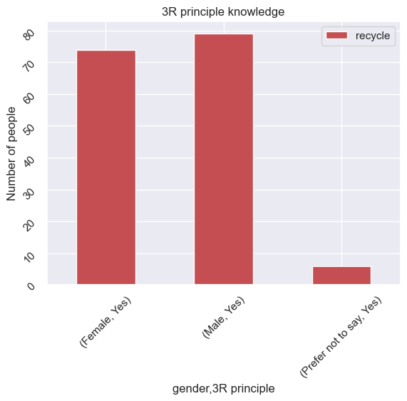

```python
table.plot(kind='bar',color='r')
mp.title('3R principle knowledge')
mp.tick_params(rotation=45)
mp.ylabel('Number of people')
mp.show()
```

### DOT PLOTS:

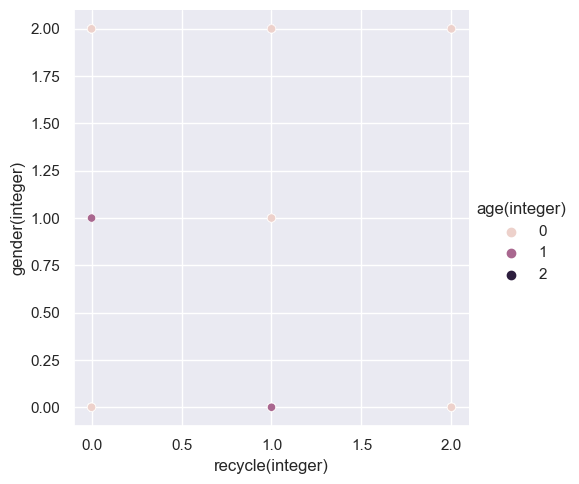

```python
sns.relplot(x='recycle(integer)',y='gender(integer)',hue='age(integer)',data=variable);
```

### CORRELATION DIAGRAM

one thing to be noted here is that 1 means strong relation 0 means no relation

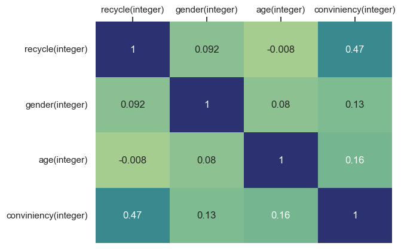

```python
variable_corr=variable.corr()
ax=sns.heatmap(variable_corr,cmap="crest",annot=True,cbar=False)
ax.xaxis.tick_top()
```

## FREQUENCY DISTRIBUTION:

### After making all the plots for the data the next step was frequency distribution of the data in numeric form

For this purpose we used data that was converted in numeric form

```python
sns.set(font_scale=1)
def freq_dist(df):
    for col in variable.columns:
        if pd.api.types.is_numeric_dtype(variable[col]):
            g=np.histogram(variable[col],bins=5,density=False)
            col1=[]
            col2=[]
            for i in range(len(g[0])):
                col1.append(g[0][i])
                col2.append(f'{round(g[1][i],2)} - {round(g[1][i+1],2)}')
            l=pd.DataFrame({f'{col}_distribution':col2,'freq':col1})
            l.set_index(f'{col}_distribution', inplace=True)
            display(l)
            sns.displot(variable[col], kde=True,bins=5).set(title=col)
            mp.show()
```

In the above diagram on x - axis 0 indicate yes, 1 indicate sometimes, 2 indicates no, Similarly all the frequency distribution plots given below are according to the coding keys given above in the outlier handling part.

| recycle(integer)_distribution | freq |
| --- | --- |
| 0.0 - 0.4 | 80 |
| 0.4 - 0.8 | 0 |
| 0.8 - 1.2 | 91 |
| 1.2 - 1.6 | 0 |
| 1.6 - 2.0 | 60 |

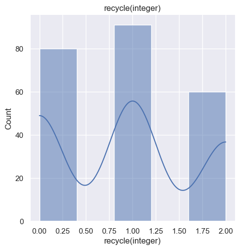

| gender(integer)_distribution | freq |
| --- | --- |
| 0.0 - 0.4 | 106 |
| 0.4 - 0.8 | 0 |
| 0.8 - 1.2 | 6 |
| 1.2 - 1.6 | 0 |
| 1.6 - 2.0 | 119 |

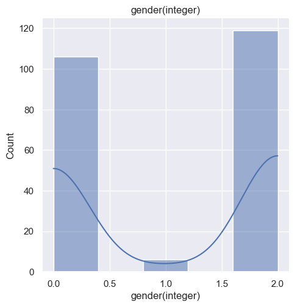

| age(integer)_distribution | freq |
| --- | --- |
| 0.0 - 0.4 | 107 |
| 0.4 - 0.8 | 0 |
| 0.8 - 1.2 | 108 |
| 1.2 - 1.6 | 0 |
| 1.6 - 2.0 | 16 |

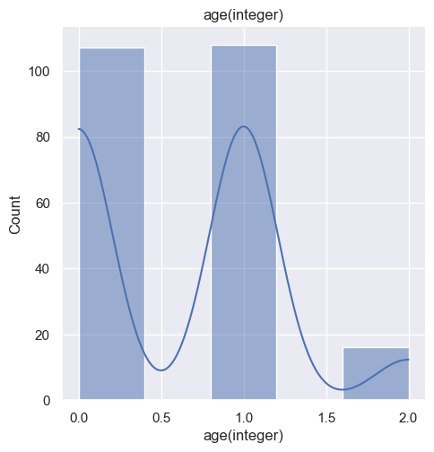

| conviniency(integer)_distribution | freq |
| --- | --- |
| 0.0 - 0.4 | 102 |
| 0.4 - 0.8 | 0 |
| 0.8 - 1.2 | 84 |
| 1.2 - 1.6 | 0 |
| 1.6 - 2.0 | 45 |

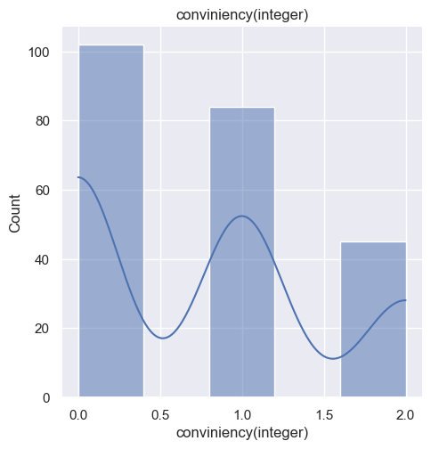

```python
freq_dist(variable)
```

## HYPOTHESIS TESTING

### HYPOTHESIS 1: Recycling is more convinient for males as compared to other genders

Let's take our null hypothesis as :

### H0:

p= The proprtion of people who find recycling convenient are males.

### H1:

p= The proportion of people who find recycling convinient are not males.

#### For hypothesis 1 we used z test score .

```python
recycle=variable[variable['conviniency']=='Yes']
convinient=recycle[recycle['gender(integer)']==2]
prop_convinient=round(len(convinient)/len(recycle),2)
```

```python
prop_convinient
```

```
0.48
```

```python
so_boot_distn=[]
for i in range(1000):
    so_boot_distn.append(
    np.mean(
    recycle.sample(frac=1,replace=True)['recycle(integer)']
    )
    )
std_error=np.std(so_boot_distn,ddof=1)
```

##### The standard error is calculated using bootstrap distribution

### We are testing the hypothesis on confidence interval of 95% i.e at alpha=0.05

```python
std_error
```

```
0.06868306881744088
```

```python
z=round((prop_convinient-0.95)/std_error,2)
z
```

```
-6.84
```

```python
p=norm.cdf(z,loc=0,scale=1)
p=p*2
p
```

```
7.919318050871721e-12
```

### CONCLUSION :

##### As p<0.05 so we can say that "we have sufficient evidence to reject the null hypothesis that the people who find recycling convinient are males.

## HYPOTHESIS 2: Men don't find recycling convinient

For the second hypothesis we took our null hypothesis as :

##### H1: p= those who recycle are males

#### For second hypothesis testing we used t distribution , for this purpose we needed to first calculate the sampla mean , then the t score and at last the p value for our hypothesis

```python
no_recycle=variable[variable['conviniency']=='No']
sample_mean=round(no_recycle['gender(integer)'].mean(),2)
sample_mean
```

```
1.38
```

```python
so_boot_distn=[]
for i in range(1000):
    so_boot_distn.append(
    np.mean(
    no_recycle.sample(frac=1,replace=True)['recycle(integer)']
    )
    )
std_error=np.std(so_boot_distn,ddof=1)
```

```python
std_error
```

```
0.09775188988037553
```

```python
T=round((sample_mean-0.5)/std_error,2)
T
```

```
9.0
```

```python
p=t.cdf(T,df=(len(no_recycle)-1))
p
```

```
0.9999999999922398
```

#### Thats all from our side of the project, thanks for visiting it :)